# PSpecteR Manual v.2019.10.07

Degnan, David J

10/7/2019

## PSpecteR Description

Briely, PSpecteR is a proteomic data visualization application which generates mass spectra and other graphics from mass spec files (mzML, mzXML, ThermoFisher raw), spectra-associated protein ID files (mzid), and fasta database files (fa, fasta).

### Abstract

The preferred method to identify and quantify expressed proteins within biological systems is liquid chromatography coupled to mass spectrometry (LC-MS), where either intact or digested proteins are eluted from an LC column, ionized, and analyzed with MS. The resulting LC-MS data files are compressed in binary formats (.raw) and thus require specialized analysis software which complicates data visualization and quality control processes. Using existing packages in R, we developed PSpecteR: a graphical user interface (GUI) to interact with proteomic LC-MS ThermoFisher .raw files. PSpecteR allows users to import .raw or XML-formatted MS data and either call a protein identification algorithm to match the spectra to amino acid sequences from a fasta database (e.g., MSPathFinder or MSGF+) or provide the identification results (i.e., .mzid). Using peptide-spectrum matches, raw MS/MS spectra are automatically annotated with multiple in-silico fragment ions of peptides that the user can interactively chose and change. PSpecteR also offers multiple interactive visualizations of MS data and the exportation of all figures, tables, and spectra. PSpecteR is a user- and coder-friendly GUI which demonstrates that, like code, GUIs can be flexible and open source.

## App Installation

### Install App on Windows

1. Go to the google drive and copy the “PSpecteR” folder to your desktop. [Link to the PSpecteR Google Drive](https://drive.google.com/drive/u/1/folders/1Z8Zv6yF_SIWbOFk7Y-v9iuO7XF_rbO_v).
2. On your desktop, click PSpecteR’s “LaunchApp” folder followed by the “R_Version” folder. Download R 3.6.1 by clicking “R-3.6.1-win.exe.” This should take about 20 seconds.
3. After completing the previous step, this is the only step you need to complete whenever launching the app again. Return to the “Launch App” folder and click “LAUNCH_windows.bat.” All the dependencies should install for you, and the app will automatically open in your web browser. For your own reference, a table will print during an succesful upload.

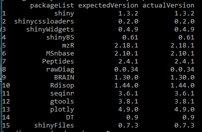

### Install App on macOS

1. Go to the google drive and copy the “PSpecteR” folder to your desktop. [Link to the PSpecteR Google Drive](https://drive.google.com/drive/u/1/folders/1Z8Zv6yF_SIWbOFk7Y-v9iuO7XF_rbO_v).
2. On your desktop, click PSpecteR’s “LaunchApp” folder followed by the “R_Version” folder. Download R 3.6.1 by clicking “R-3.6.1.pkg.” This should take about 20 seconds.
3. After completing the previous step, this is the only step you need to complete whenever launching the app again. Return to the “Launch App” folder and click “LAUNCH_macOS.command.” All the dependencies should install for you, and the app will automatically open in your web browser. For your own reference, a table will print during an succesful upload.

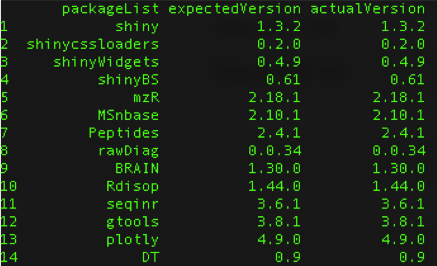

### Reasons why the app might not have opened the first time

1. The “LAUNCH” files check that the right version of R is installed. A warning will let you know if the wrong version is being used.
2. If you have Bioconductor, the shell or command.exe version of R will need to be updated. This can be googled and completed in the command line.
3. If it isn’t these two errors, please let me know at david.degnan@pnnl.gov. Thanks!

## 1. Upload Files Page

### Page Description

This page allows you to upload mass spec (MS) files, protein ID (ID) files, and protein database files (FA). You can choose to use pre-loaded test files at the bottom of the page. One tests the entire app and the other only tests the MSGF+ peptide database search algorithm.

### How to Use

1. Click the “1. Upload” option in the navigation bar at the top of the page.

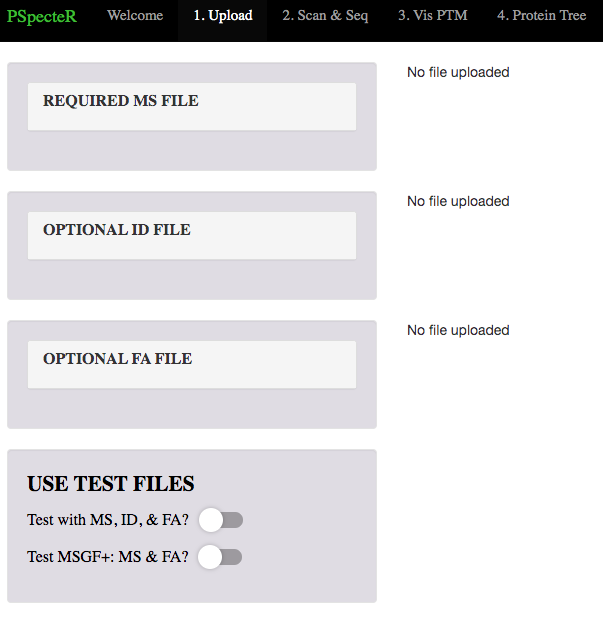

2. Click the “Required MS File” text to open the collapsible side bar.

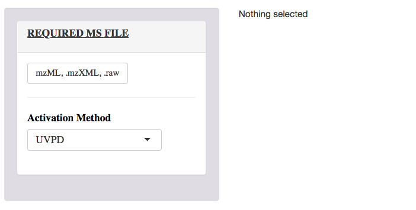

3. Click the “.mzML, .mzXML, .raw” button to open your directory. Click on any of the aforementioned file types and then click “open.”

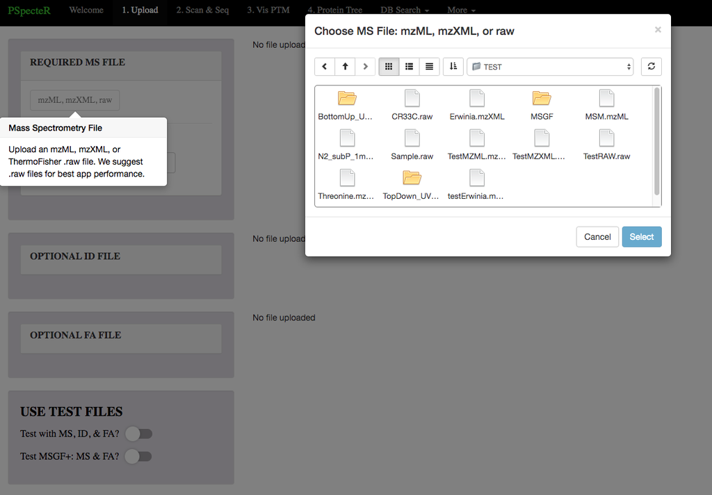

4. A successful load will be indicated with a print out of the file path on the right.

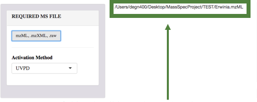

5. Select activation method with a drop down-box.

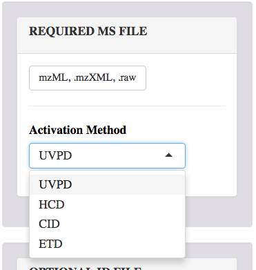

6. The MS file can be visualized with Scan & Seq. Users may add ID data. Note than an unsupported file type is given with a warning.

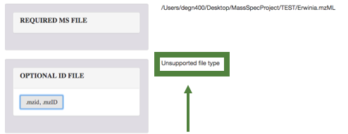

7. Pre-loaded test files are available. If you would like to test the app with an already generated .mzid file, click the first test file slider and proceed to 2. Scan & Seq.

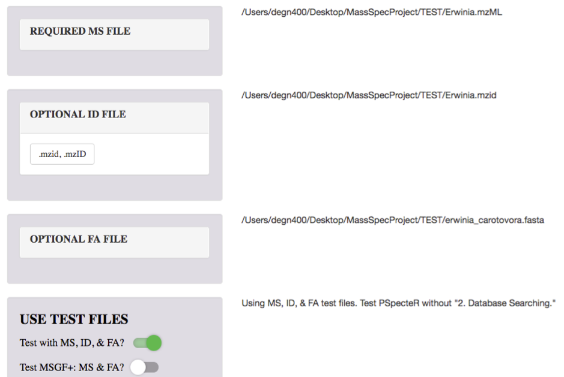

8. If you would like to test peptide database search tool MSGF+, click the second slider to load a small .mzML file and a FA database file.

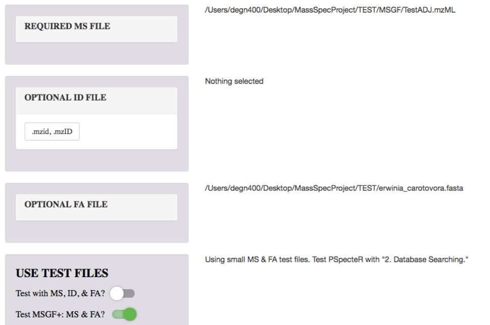

## 2. Scan & Seq Page

### Page Description

Scan & Seq allows you to see how well a peptide sequence maps to a specific MS2 (or MS1) scan. Visualize fragmentation patterns, post-translational modifications, extracted ion chromatograms, the best identified fragment ion per peptide, and more.

### Set Filters

1. Click the **1. Filtering Settings** box and ensure the right Ion Types have been selected. Notice that they are pre-selected based on the previously chosen Activation Method in the Upload Page.

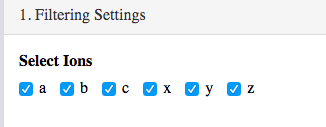

2. **Spectrum Ranges:** You may zoom in on the image by using the sliders or by typing in a value or range for either the intensity or m/z. Click the update buttons after typing in a value. You must input these values when taking an image snapshot to save the image for later. Otherwise, the entire image will export and not one with a zoomed in range.

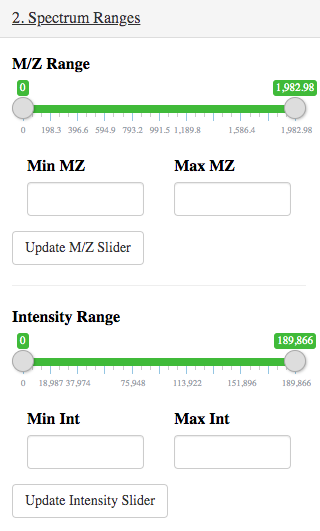

3. **Spectrum Settings:** Set the fragment tolerance (how far off theoeretical fragments can be from experimental fragments in PPM). Then set the minimum intensity value that will be plotted. The minimum isotopic percentage is the smallest isotopic peak size that will be visualized based on percentage of size as compared to the highest peak. Set this value, and then choose whether you would like the traditional spectra view or not. When viewing MS1 scans, it is highly recommended that you disable this feature. Also, choose whether you would like to annotate the spectra with its fragment name (not fully functional yet).

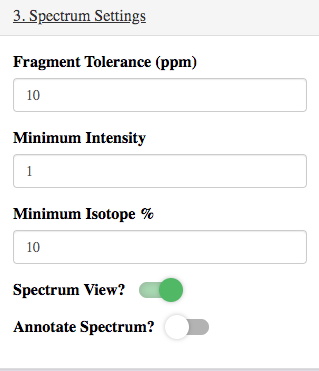

4. **XIC Ranges:** Set the XIC ranges, similar to 2.2 Spectrum Ranges.

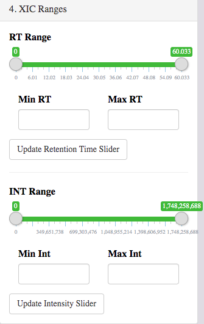

5. **XIC Settings:** An XIC (extracted ion chromatogram) graphs the intensity vs retention time peaks across all MS1 scans with the XIC MZ value. The XIC MZ Value here is autofilled with the MSn scan’s Precursor MZ (Pre.MZ) value. The XIC Charge value plots the traces for m+n peaks that are XIC MZ value + n * 1/XIC Charge. The Precursor Tolerance is how large the search window is to identify the peak across MS1 scans.

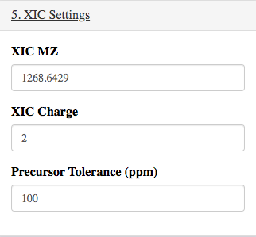

6. **Sequence Settings:** Select the background color for the “All Ions” graphic. Next, input a sequence if you would like to try one. B, J, O, U, X, and Z are not accetable amino acids, and the sequence must have at least two letters. It cannot contain spaces or extra characters.

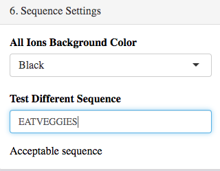

7. **Scan (Table) Settings:** Choose which columns of the Scan Table you would like to see. Column options can be searched, all selected, or all deselected.

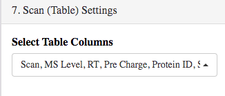

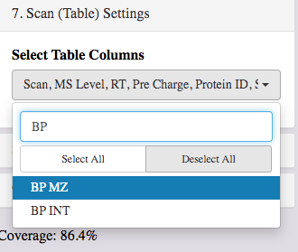

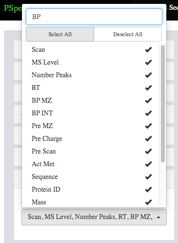

8. **Take Image Snapshot:** Take high-res snapshots of the rendered plots. Remember to zoom in with the ranges options, if applicable. These images can be exported. See “Exportations” to learn how.

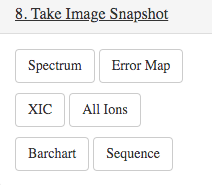

9. **Export Data:** Click one of these buttons to convert the XML data to a CSV. See “Exportations” to learn how.

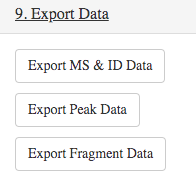

### View Graphics

10. **Spectrum:** Hover over the image and zoom by dragging a box over where you would like to zoom in. Click the Autoscale button to return to the original view. All graphics in PSpecteR can be zoomed and only have certain datapoints selected. Hover over the peaks to get the identified ion name, m/z value, and intensity value. Settings 1-3 in the sidebar control the inputs to generate this graphic. Specific fragments can be selected with the table under “Tab.”

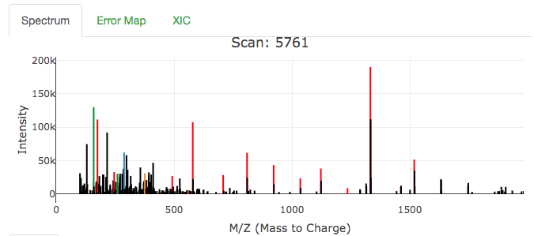

11. **Heatmap:** See the ppm error (how far off the theoretical value is from the experimental value) per amino acid per ion type. PPM error is calculated by (exp - theo / theo * 1e6).

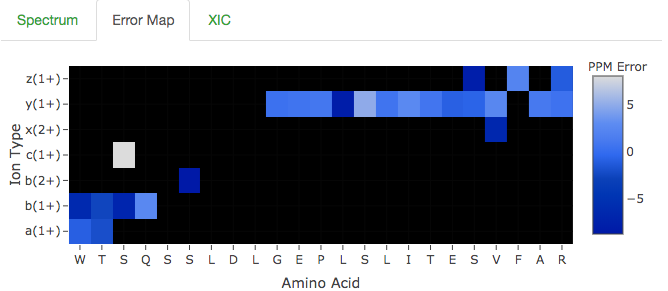

12. **XIC:** An XIC (extracted ion chromatogram) graphs the intensity vs retention time peaks across all MS1 scans for peaks with the XIC MZ value.

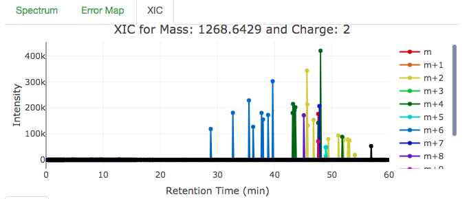

13. **All Ions:** See all identified ion types per amino acid. Hover-over to see ion type, and m/z and intensity values.

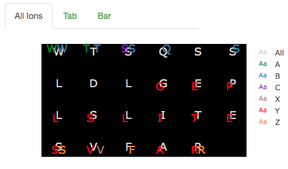

14. **Tab:** This table allows the user to see all identified fragments. Click table rows to have the data isolated by ion type (not fully functional). Tables can be sorted by clicking the down and up arrows by the column titles.

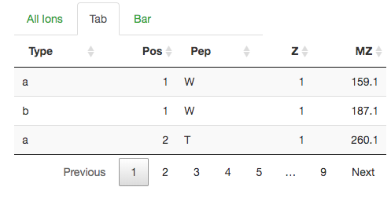

15. **Bar:** See a barchart of all identified ion types.

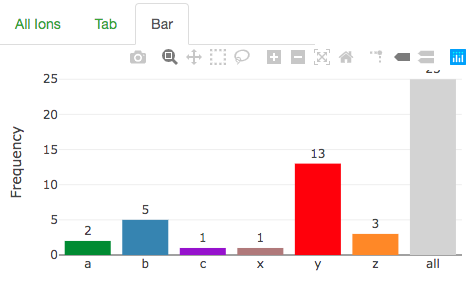

16. **Scan:** Click a row to visualize the data assoicated with a specific scan. Add/remove columns to the table with “Scan (Table) Settings.” Tables can be searched (dialog boxes) and sorted (arrows). To select a range, like from 3 to 5, type `3 ... 5` into the search box.

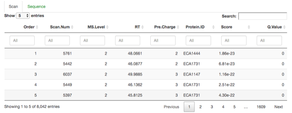

17. **Sequence:** View the best fit (lowest ppm error) a,b,c or x,y,z ion per amino acid. Hover-over to see the PPM error of each fragment.

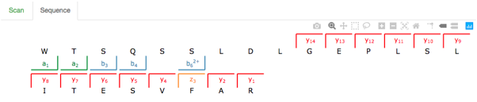

## 3. Visualize Post-Translational Modifications Page

**PAGE NOT COMPLETE**

### Set Filters

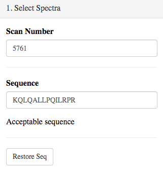

2. **Choose Modifications:** Select all desired modifications (up to 15) that you would like to be tested. This selection box is exactly like 2.7 Scan (Table) Settings without a select all option. The most common PTMs are listed at the top and can be easily selected with the “Common PTMs” button. Use clear to remove all selected PTMs. Extra PTMs can be added in “C. Unimod Glossary” under the More tab. You can also set the max number of modifications per sequence and max number of modifications per peptide (not functional). We encourage you to test out what you can of this page.

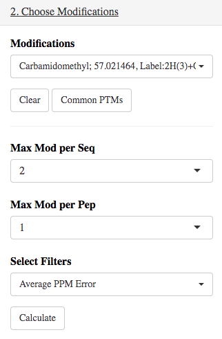

3. The rest of this page is coming soon!